### Data science fundamentals 05: Wrangle data (Oct. 05, 2017)

#### A note on tibbles

We already saw tibbles and how to convert data frames into tibbles (using `as.tibble()`). Tibbles have a refined print method that shows only the first 10 rows, and all the columns that fit on screen.

```r
  # Load the package RCurl
  library(RCurl)
  # Import the HANES data set from GitHub; break the string into two for readability
  # (Please note this readability aspect very carefully)
  URL_text_1 <- "https://raw.githubusercontent.com/kannan-kasthuri/kannan-kasthuri.github.io"
  URL_text_2 <- "/master/Datasets/HANES/NYC_HANES_DIAB.csv"
  # Paste it to constitute a single URL
  URL <- paste(URL_text_1,URL_text_2, sep="")
  HANES <- read.csv(text=getURL(URL))
  # Rename the GENDER factor for identification
  HANES$GENDER <- factor(HANES$GENDER, labels=c("M","F"))
  # Rename the AGEGROUP factor for identification
  HANES$AGEGROUP <- factor(HANES$AGEGROUP, labels=c("20-39","40-59","60+"))
  # Rename the HSQ_1 factor for identification
  HANES$HSQ_1 <- factor(HANES$HSQ_1, labels=c("Excellent","Very Good","Good", "Fair", "Poor"))
  # Rename the DX_DBTS as a factor
  HANES$DX_DBTS <- factor(HANES$DX_DBTS, labels=c("DIAB","DIAB NO_DX","NO DIAB"))
  # Omit all NA from the data frame
  HANES <- na.omit(HANES)
  # Observe the structure
  str(HANES)
  # Load the tidyverse library
  library(tidyverse)
```

```r
  # Load the package RCurl
  library(RCurl)
  # Import the HANES data set from GitHub; break the string into two for readability
  # (Please note this readability aspect very carefully)
  URL_text_1 <- "https://raw.githubusercontent.com/kannan-kasthuri/kannan-kasthuri.github.io"
  URL_text_2 <- "/master/Datasets/HANES/NYC_HANES_DIAB.csv"
  # Paste it to constitute a single URL
  URL <- paste(URL_text_1,URL_text_2, sep="")
  HANES <- read.csv(text=getURL(URL))
  # Rename the GENDER factor for identification
  HANES$GENDER <- factor(HANES$GENDER, labels=c("M","F"))
  # Rename the AGEGROUP factor for identification
  HANES$AGEGROUP <- factor(HANES$AGEGROUP, labels=c("20-39","40-59","60+"))
  # Rename the HSQ_1 factor for identification
  HANES$HSQ_1 <- factor(HANES$HSQ_1, labels=c("Excellent","Very Good","Good", "Fair", "Poor"))
  # Rename the DX_DBTS as a factor
  HANES$DX_DBTS <- factor(HANES$DX_DBTS, labels=c("DIAB","DIAB NO_DX","NO DIAB"))
  # Omit all NA from the data frame
  HANES <- na.omit(HANES)
  # Observe the structure
  str(HANES)
```

```
## 'data.frame':    1112 obs. of  23 variables:
##  $ KEY              : Factor w/ 1527 levels "133370A","133370B",..: 28 43 44 53 55 70 84 90 100 107 ...
##  $ GENDER           : Factor w/ 2 levels "M","F": 1 1 1 1 1 1 1 1 1 1 ...
##  $ SPAGE            : int  29 28 27 24 30 26 31 32 34 32 ...
##  $ AGEGROUP         : Factor w/ 3 levels "20-39","40-59",..: 1 1 1 1 1 1 1 1 1 1 ...
##  $ HSQ_1            : Factor w/ 5 levels "Excellent","Very Good",..: 2 2 2 1 1 3 1 2 1 3 ...
##  $ UCREATININE      : int  105 53 314 105 163 150 46 36 177 156 ...
##  $ UALBUMIN         : num  0.707 1 8 4 3 2 2 0.707 4 3 ...
##  $ UACR             : num  0.00673 2 3 4 2 ...
##  $ MERCURYU         : num  0.37 0.106 0.487 2.205 0.979 ...
##  $ DX_DBTS          : Factor w/ 3 levels "DIAB","DIAB NO_DX",..: 3 3 3 3 3 3 3 3 3 3 ...
##  $ A1C              : num  5 5.2 4.8 5.1 4.3 5.2 4.8 5.2 4.8 5.2 ...
##  $ CADMIUM          : num  0.2412 0.1732 0.0644 0.0929 0.1202 ...
##  $ LEAD             : num  1.454 1.019 0.863 1.243 0.612 ...
##  $ MERCURYTOTALBLOOD: num  2.34 2.57 1.32 14.66 2.13 ...
##  $ HDL              : int  42 51 42 61 52 50 57 56 42 44 ...
##  $ CHOLESTEROLTOTAL : int  184 157 145 206 120 155 156 235 156 120 ...
##  $ GLUCOSESI        : num  4.61 4.77 5.16 5 5.11 ...
##  $ CREATININESI     : num  74.3 73 80 84.9 66 ...
##  $ CREATININE       : num  0.84 0.83 0.91 0.96 0.75 0.99 0.9 0.84 0.93 1.09 ...
##  $ TRIGLYCERIDE     : int  156 43 108 65 51 29 31 220 82 35 ...
##  $ GLUCOSE          : int  83 86 93 90 92 85 72 87 96 92 ...
##  $ COTININE         : num  31.5918 0.0635 0.035 0.0514 0.035 ...
##  $ LDLESTIMATE      : int  111 97 81 132 58 99 93 135 98 69 ...
##  - attr(*, "na.action")=Class 'omit'  Named int [1:415] 2 15 16 24 26 28 33 34 35 39 ...
##   .. ..- attr(*, "names")= chr [1:415] "2" "15" "16" "24" ...
```

```r
  # Load the tidyverse library
  library(tidyverse)
```

To subset a variable name in a pipe, we have to use a special placeholder `.` when we use tibble.

```r
  # Convert HANES to tibble
  HANES_tibble <- as.tibble(HANES)
  # Subset A1C variable from the tibble HANES
  HANES_A1C <- HANES_tibble %>% .$A1C
  # You can set the print options for the
  # number of lines to be printed
  options(tibble.print_min = 7)
  as.tibble(HANES_A1C)
```

```
## # A tibble: 1,112 x 1
##   value
##   <dbl>
## 1   5.0
## 2   5.2
## 3   4.8
## 4   5.1
## 5   4.3
## 6   5.2
## 7   4.8
## # ... with 1,105 more rows
```

#### Reading files and parsing

Comma Seperated Values (CSV) are the most common types of files. We can read a `.csv` file through the function `read_csv()`.

```r
  # Read the HANES orginal csv file
  HANES_original <- read.csv("../Datasets/HANES/HANES.original.csv")
  # and convert into tibble
  as.tibble(HANES_original)
```

```
## # A tibble: 1,527 x 704
##       KEY BOROSTRATUM PSUNEST HHNEST  CAPI_WT  EXAM_WT BLOOD_WT URINE_WT
## *  <fctr>       <int>   <int>  <int>    <dbl>    <dbl>    <dbl>    <dbl>
## 1 134040A           1      80 134040 7124.351 7421.006 8529.362 7811.598
## 2 134240B           1      82 134240 3946.733 4045.217 4696.925 4174.914
## 3 134460B           1      83 134460 3795.282 3859.116 4262.829 3854.439
## 4 134490A           1      83 134490 3946.733 4045.217 4696.925 4174.914
## 5 134620A           1      84 134620 3795.282 3859.116 4262.829 3854.439
## 6 134670A           1      84 134670 3795.282 3859.116 4262.829 3854.439
## 7 135210B           1      86 135210 3946.733 4045.217 4696.925 4174.914
## # ... with 1,520 more rows, and 696 more variables: SALIVA_WT <dbl>,
## #   ACASI_WT <dbl>, WT_CAPI <int>, WT_EXAM <int>, WT_BLOOD <int>,
## #   WT_URINE <int>, WT_SALIVA <int>, WT_ACASI <int>, LAQ1 <int>,
## #   IS_PROXY <int>, GENDER <int>, SPAGE <int>, AGEGROUP <int>,
## #   AGEGRP3C <int>, AGEGRP4C <int>, AGEGRP5C <int>, DMQ_A <int>,
## #   DMQ_1 <int>, EDUCATION <int>, EDU4CAT <int>, EDU3CAT <int>, EDU <int>,
## #   DMQ_2 <int>, MARITAL <int>, MARITALMOD <int>, DMQ_3 <int>,
## #   DMQ_5 <fctr>, DMQ_5A <fctr>, US_BORN <int>, BORN <int>, DMQ_6 <fctr>,
## #   DMQ_7MON <int>, DMQ_7YEAR <int>, DMQ_8MON <int>, DMQ_8YEAR <int>,
## #   DMQ_9MON <int>, DMQ_9YEAR <int>, DMQ_10 <fctr>, DMQ_10A <fctr>,
## #   DMQ_11 <fctr>, DMQ_11A <fctr>, DMQ_12 <int>, DMQ_13_1 <int>,
## #   DMQ_13_2 <int>, DMQ_13_3 <int>, DMQ_13OTH <fctr>, DMQ_14_1 <int>,
## #   DMQ_14_2 <int>, DMQ_14_3 <int>, DMQ_14OTH <fctr>, RACE <int>,
## #   RACECKDEPI <int>, ASIAN <int>, DMQ_15 <int>, DMQ_16_1 <int>,
## #   DMQ_16_2 <int>, DMQ_16OTH <fctr>, HSQ_1 <int>, HSQ_2 <int>,
## #   HSQ_3 <int>, HSQ_4 <int>, HSQ_5 <int>, HSQ_6 <int>, HSQ_7 <int>,
## #   HSQ_8 <int>, OCQ_1 <int>, OCQ_2 <int>, OCQ_3 <int>, OCQ_4 <fctr>,
## #   OCQ_5 <fctr>, OCQ_6 <int>, OCQ_7 <int>, OCQ_8 <int>, OCQ_9 <int>,
## #   OCQ_10 <int>, HIQ_1 <int>, HIQ_2_1 <int>, HIQ_2_2 <int>,
## #   HIQ_2_3 <int>, HIQ_3_1 <int>, HIQ_4 <int>, HIQ_5 <int>, HIQ_6 <int>,
## #   HIQ_7 <int>, HIQ_8_1 <int>, HIQ_8_2 <int>, HIQ_8_3 <int>,
## #   HIQ_8OTH <fctr>, HUQ_1 <int>, HUQ_2 <int>, HUQ_3 <int>, HUQ_4 <int>,
## #   HUQ_5 <int>, HUQ_6 <int>, HUQ_9 <int>, HUQ_10 <int>, HUQ_11 <int>,
## #   HUQ_12 <int>, MEDS_1_HUQ_13A <fctr>, MEDS_1_HUQ_13B <int>, ...
```

Parsing a vector can be done through the parsing function:

```r
  # Parse a logical vector
  str(parse_logical(c("TRUE", "FALSE", "NA")))
  # Parse an integer vector
  # Actually EDUCATION is a factor variable
  str(parse_integer(HANES_original$EDUCATION))
  # Parse a date vector
  str(parse_date(c("2010-01-01", "1979-10-14")))
```

```
##  logi [1:3] TRUE FALSE NA
```

```
##  int [1:1527] 2 3 3 3 3 3 3 3 3 3 ...
```

```
##  Date[1:2], format: "2010-01-01" "1979-10-14"
```

We can specify which education categories should be treated as NA. For instance, if we wish to denote all high schoolers (category 2) as NA:

```r
  # Replace EDUCATION variable with high schoolers as NA
  as.tibble(parse_integer(HANES_original$EDUCATION, na = "2"))
```

```
## # A tibble: 1,527 x 1
##   value
##   <int>
## 1    NA
## 2     3
## 3     3
## 4     3
## 5     3
## 6     3
## 7     3
## # ... with 1,520 more rows
```

If parsing fails we will get a warning:

```r
  # Parse EDUCATION as a logical when it is a number
  parse_logical(HANES_original$EDUCATION)
```

[output not shown]

which can be output into a tibble format using the `problems()` function:

```r
  # Parse EDUCATION as a logical when it is a number
  x <- parse_logical(HANES_original$EDUCATION)
  # and output the result as a nice tibble
  problems(x)
```

```
## # A tibble: 1,209 x 4
##     row   col           expected actual
##   <int> <int>              <chr>  <chr>
## 1     1    NA 1/0/T/F/TRUE/FALSE      2
## 2     2    NA 1/0/T/F/TRUE/FALSE      3
## 3     3    NA 1/0/T/F/TRUE/FALSE      3
## 4     4    NA 1/0/T/F/TRUE/FALSE      3
## 5     5    NA 1/0/T/F/TRUE/FALSE      3
## 6     6    NA 1/0/T/F/TRUE/FALSE      3
## 7     7    NA 1/0/T/F/TRUE/FALSE      3
## # ... with 1,202 more rows
```

Parsing different number formats are important as it comes in various styles:

1. People write numbers differently in different parts of the world. For example, some countries use . in between the integer and fractional parts of a real number, while others use ,.
2. Numbers are often surrounded by other characters that provide some context, like “$1000” or “10%”.
3. Numbers often contain “grouping” characters to make them easier to read, like “1,000,000”, and these grouping characters vary around the world.

The first problem is solved by the argument `locale` in `parse_double()` function, the second using `parse_number()` function and the third by combination of `locale` and `parse_number()`.

```r
  # Parse the number 1,23 where the decimal mark is written as a `,`
  parse_double("1,63", locale = locale(decimal_mark = ","))
  # Just parse the number for $120 and 60%
  parse_number("$120")
  parse_number("60%")
  # Parse the grouping as used in Europe
  parse_number("123'834'297", locale = locale(grouping_mark = "."))
  # or as used in Switzerland
  parse_number("123'834'297", locale = locale(grouping_mark = "'"))
```

```
## [1] 1.63
```

```
## [1] 120
```

```
## [1] 60
```

```
## [1] 123
```

```
## [1] 123834297
```

All data sets are stored with encoding. Each hexadecimal number represents a byte of information: 48 is H, 61 is a, and so on.

The mapping from hexadecimal number to character is called the encoding, and in the case of english the standard of encoding is ASCII.

The function `charToRaw()` will list the encoding of characters in the ASCII format.

```r
  # The function charToRaw will list the encoding of charecters in ASCII format
  charToRaw("This is a nice day")
```

```
##  [1] 54 68 69 73 20 69 73 20 61 20 6e 69 63 65 20 64 61 79
```

However, we need encodings for other languages and UTF-8 is the standard that can encode just about every character used by humans today, as well as many extra symbols (like emoji!).

We can parse such encodings (that will appear gibberish if we read it in the english system) through `parse_charecter()` function:

```r
  # Define other encoded strings
  x1 <- "El Ni\xf1o was particularly bad this year"
  x2 <- "\x82\xb1\x82\xf1\x82\xc9\x82\xbf\x82\xcd"
  # Parse those strings
  parse_character(x1, locale = locale(encoding = "Latin1"))
  parse_character(x2, locale = locale(encoding = "Shift-JIS"))
  # We can even guess the encodings, if they are not available
  guess_encoding(charToRaw(x1))
  guess_encoding(charToRaw(x2))
```

```
## [1] "El Niño was particularly bad this year"
```

```
## [1] "こんにちは"
```

```
## # A tibble: 2 x 2
##     encoding confidence
##        <chr>      <dbl>
## 1 ISO-8859-1       0.46
## 2 ISO-8859-9       0.23
```

```
## # A tibble: 1 x 2
##   encoding confidence
##      <chr>      <dbl>
## 1   KOI8-R       0.42
```

We see that KOI8-R is an 8-bit character encoding, designed to cover Russian, which uses a Cyrillic alphabet.

Parsing date and time is very important in health related data sets. For example, the MIMIC3 data has tons of data sets with time information. There are three main functions for parsing dates and times.

- `parse_datetime()` expects an ISO8601 date-time. ISO8601 is an international standard in which the components of a date are organised from biggest to smallest: year, month, day, hour, minute, second.
- `parse_date()` expects a four digit year, a - or /, the month, a - or /, then the day
- `parse_time()` expects the hour, :, minutes, optionally : and seconds, and an optional am/pm specifier

```r
  # Parse datetime
  parse_datetime("2010-10-01T2010")
  # Parse date
  parse_date("2010-10-01")
  # Parse time
  library(hms)
  parse_time("01:10 am")
```

```
## [1] "2010-10-01 20:10:00 UTC"
```

```
## [1] "2010-10-01"
```

```
## 01:10:00
```

If the deafults doesn’t work, there are several options as follows:

- Year: %Y (4 digits), %y (2 digits); 00-69 -> 2000-2069, 70-99 -> 1970-1999.
- Month: %m (2 digits), %b (abbreviated name, like “Jan”), %B (full name, “January”).
- Day: %d (2 digits), %e (optional leading space).
- Time: %H 0-23 hour, %I 0-12, must be used with %p, %p AM/PM indicator, %M minutes, %S integer seconds, %OS real seconds, %Z Time zone (as name, e.g. America/Chicago).
- Non-digits: %. skips one non-digit character, %* skips any number of non-digits.

As an example:

```r
  # Parse date in month/day/year format
  parse_date("01/02/15", "%m/%d/%y")
  # Parse date in day/month/year format
  parse_date("01/02/2015", "%d/%m/%Y")
  # Parse date in year/month/date format
  parse_date("01/02/15", "%y/%m/%d")
  # We can even set the `locale` option to specify different built in languages for the date
  parse_date("1 janvier 2015", "%d %B %Y", locale = locale("fr"))
```

```
## [1] "2015-01-02"
```

```
## [1] "2015-02-01"
```

```
## [1] "2001-02-15"
```

```
## [1] "2015-01-01"
```

**Classwork/Homework**: Read section 11.4 and 11.5 in the R for Data Science book.

#### Dealing with dates and times

Dealing with dates and times can be a very tough job. For example, consider the MIMIC3 admissions table which has several time variables.

**Note**: MIMIC3 says “dates were shifted into the future by a random offset for each individual patient in a consistent manner to preserve intervals, resulting in stays which occur sometime between the years 2100 and 2200.” so don’t freak out looking at the dates.

If we import the dataset as such, we will see that they import as a factor and the `parse_date()` function as such fails:

```r
  # Load the package RCurl
  library(RCurl)
  # Import the admissions data set in MIMIC3 from GitHub;
  URL_text_1 <- "https://raw.githubusercontent.com/kannan-kasthuri/kannan-kasthuri.github.io"
  URL_text_2 <- "/master/Datasets/MIMIC3/admissions.csv"
  URL <- paste(URL_text_1,URL_text_2, sep="")
  MIMIC3_ADM <- read.csv(text=getURL(URL))
  # Observe the structure
  str(MIMIC3_ADM)
  # Parse the admission time using `parse_date()` function
  head(parse_date(MIMIC3_ADM$admittime, "%Y%m%d%e"))
```

```
## 'data.frame':    5770 obs. of  19 variables:
##  $ row_id              : int  83 84 85 86 87 88 89 90 91 92 ...
##  $ subject_id          : int  82 83 84 84 85 85 86 87 88 89 ...
##  $ hadm_id             : int  110641 158569 120969 166401 116630 112077 190243 190659 123010 188646 ...
##  $ admittime           : Factor w/ 5310 levels "2100-07-04","2100-07-09",..: 2665 2240 5030 5037 3331 3607 2458 4778 569 4458 ...
##  $ dischtime           : Factor w/ 5767 levels "2100-07-17 15:00:00",..: 2878 2415 5462 5469 3603 3901 2651 5204 609 4834 ...
##  $ deathtime           : Factor w/ 569 levels "2100-09-13 21:20:00",..: NA NA NA 538 NA NA NA NA NA NA ...
##  $ admission_type      : Factor w/ 4 levels "ELECTIVE","EMERGENCY",..: 3 4 1 2 2 2 1 3 2 3 ...
##  $ admission_location  : Factor w/ 9 levels "** INFO NOT AVAILABLE **",..: 5 6 5 3 2 2 5 5 3 5 ...
##  $ discharge_location  : Factor w/ 16 levels "DEAD/EXPIRED",..: 5 6 5 1 14 16 6 15 5 15 ...
##  $ insurance           : Factor w/ 5 levels "Government","Medicaid",..: 4 3 4 4 3 3 4 4 4 2 ...
##  $ language            : Factor w/ 28 levels "*ARM","*CDI",..: NA NA NA NA 11 11 NA NA NA NA ...
##  $ religion            : Factor w/ 17 levels "7TH DAY ADVENTIST",..: 17 17 13 13 3 3 12 17 NA 17 ...
##  $ marital_status      : Factor w/ 7 levels "DIVORCED","LIFE PARTNER",..: NA 3 3 3 3 3 5 NA NA NA ...
##  $ ethnicity           : Factor w/ 37 levels "AMERICAN INDIAN/ALASKA NATIVE",..: 27 32 33 33 33 33 33 32 10 32 ...
##  $ edregtime           : Factor w/ 3065 levels "2100-07-09 05:56:00",..: NA NA NA 2904 NA 2075 NA NA 316 NA ...
##  $ edouttime           : Factor w/ 3065 levels "2100-07-09 15:55:00",..: NA NA NA 2904 NA 2075 NA NA 316 NA ...
##  $ diagnosis           : Factor w/ 2313 levels " AORTIC ABDOMINAL ANEURYSM/SDA",..: 1505 450 1337 985 242 1642 330 1505 1920 1505 ...
##  $ hospital_expire_flag: int  0 0 0 1 0 0 0 0 0 0 ...
##  $ has_chartevents_data: int  1 1 0 1 1 1 1 1 1 1 ...
```

```
## [1] NA NA NA NA NA NA
```

Another approach is to use the helpers provided by the library *lubridate*.

They automatically work out the format once we specify the order of the component.

To use them, we have to identify the order in which year, month, and day appear in our data, then arrange “y”, “m”, and “d” in the same order.

That gives the name of the lubridate function that will parse our date.

To use this, we need to load the lubridate library.

```r
  # Load the lubridate library
  library(lubridate)
  # Since admission time has the format year/month/time, we pass ymd
  MIMIC3_ADM$admittime <- ymd(MIMIC3_ADM$admittime)
  # View the format
  str(MIMIC3_ADM)
  # Print the first few dates
  head(MIMIC3_ADM$admittime)
```

```
## 'data.frame':    5770 obs. of  19 variables:
##  $ row_id              : int  83 84 85 86 87 88 89 90 91 92 ...
##  $ subject_id          : int  82 83 84 84 85 85 86 87 88 89 ...
##  $ hadm_id             : int  110641 158569 120969 166401 116630 112077 190243 190659 123010 188646 ...
##  $ admittime           : Date, format: "2150-06-24" "2142-04-01" ...
##  $ dischtime           : Factor w/ 5767 levels "2100-07-17 15:00:00",..: 2878 2415 5462 5469 3603 3901 2651 5204 609 4834 ...
##  $ deathtime           : Factor w/ 569 levels "2100-09-13 21:20:00",..: NA NA NA 538 NA NA NA NA NA NA ...
##  $ admission_type      : Factor w/ 4 levels "ELECTIVE","EMERGENCY",..: 3 4 1 2 2 2 1 3 2 3 ...
##  $ admission_location  : Factor w/ 9 levels "** INFO NOT AVAILABLE **",..: 5 6 5 3 2 2 5 5 3 5 ...
##  $ discharge_location  : Factor w/ 16 levels "DEAD/EXPIRED",..: 5 6 5 1 14 16 6 15 5 15 ...
##  $ insurance           : Factor w/ 5 levels "Government","Medicaid",..: 4 3 4 4 3 3 4 4 4 2 ...
##  $ language            : Factor w/ 28 levels "*ARM","*CDI",..: NA NA NA NA 11 11 NA NA NA NA ...
##  $ religion            : Factor w/ 17 levels "7TH DAY ADVENTIST",..: 17 17 13 13 3 3 12 17 NA 17 ...
##  $ marital_status      : Factor w/ 7 levels "DIVORCED","LIFE PARTNER",..: NA 3 3 3 3 3 5 NA NA NA ...
##  $ ethnicity           : Factor w/ 37 levels "AMERICAN INDIAN/ALASKA NATIVE",..: 27 32 33 33 33 33 33 32 10 32 ...
##  $ edregtime           : Factor w/ 3065 levels "2100-07-09 05:56:00",..: NA NA NA 2904 NA 2075 NA NA 316 NA ...
##  $ edouttime           : Factor w/ 3065 levels "2100-07-09 15:55:00",..: NA NA NA 2904 NA 2075 NA NA 316 NA ...
##  $ diagnosis           : Factor w/ 2313 levels " AORTIC ABDOMINAL ANEURYSM/SDA",..: 1505 450 1337 985 242 1642 330 1505 1920 1505 ...
##  $ hospital_expire_flag: int  0 0 0 1 0 0 0 0 0 0 ...
##  $ has_chartevents_data: int  1 1 0 1 1 1 1 1 1 1 ...
```

```
## [1] "2150-06-24" "2142-04-01" "2196-02-02" "2196-04-14" "2162-03-02"
## [6] "2167-07-25"
```

We also see the discharge time has both date and time formats so we can use `parse_datetime()` function to convert from the factor format.

```r
  # Load the lubridate library
  library(lubridate)
  # Since discharge time has both date and time attributes we may parse using datetime function
  MIMIC3_ADM$dischtime <- parse_datetime(MIMIC3_ADM$dischtime)
  # View the format
  str(MIMIC3_ADM)
  # Print the first few dates and times
  head(MIMIC3_ADM$dischtime)
```

```
## 'data.frame':    5770 obs. of  19 variables:
##  $ row_id              : int  83 84 85 86 87 88 89 90 91 92 ...
##  $ subject_id          : int  82 83 84 84 85 85 86 87 88 89 ...
##  $ hadm_id             : int  110641 158569 120969 166401 116630 112077 190243 190659 123010 188646 ...
##  $ admittime           : Date, format: "2150-06-24" "2142-04-01" ...
##  $ dischtime           : POSIXct, format: "2150-06-29 15:00:00" "2142-04-08 14:46:00" ...
##  $ deathtime           : Factor w/ 569 levels "2100-09-13 21:20:00",..: NA NA NA 538 NA NA NA NA NA NA ...
##  $ admission_type      : Factor w/ 4 levels "ELECTIVE","EMERGENCY",..: 3 4 1 2 2 2 1 3 2 3 ...
##  $ admission_location  : Factor w/ 9 levels "** INFO NOT AVAILABLE **",..: 5 6 5 3 2 2 5 5 3 5 ...
##  $ discharge_location  : Factor w/ 16 levels "DEAD/EXPIRED",..: 5 6 5 1 14 16 6 15 5 15 ...
##  $ insurance           : Factor w/ 5 levels "Government","Medicaid",..: 4 3 4 4 3 3 4 4 4 2 ...
##  $ language            : Factor w/ 28 levels "*ARM","*CDI",..: NA NA NA NA 11 11 NA NA NA NA ...
##  $ religion            : Factor w/ 17 levels "7TH DAY ADVENTIST",..: 17 17 13 13 3 3 12 17 NA 17 ...
##  $ marital_status      : Factor w/ 7 levels "DIVORCED","LIFE PARTNER",..: NA 3 3 3 3 3 5 NA NA NA ...
##  $ ethnicity           : Factor w/ 37 levels "AMERICAN INDIAN/ALASKA NATIVE",..: 27 32 33 33 33 33 33 32 10 32 ...
##  $ edregtime           : Factor w/ 3065 levels "2100-07-09 05:56:00",..: NA NA NA 2904 NA 2075 NA NA 316 NA ...
##  $ edouttime           : Factor w/ 3065 levels "2100-07-09 15:55:00",..: NA NA NA 2904 NA 2075 NA NA 316 NA ...
##  $ diagnosis           : Factor w/ 2313 levels " AORTIC ABDOMINAL ANEURYSM/SDA",..: 1505 450 1337 985 242 1642 330 1505 1920 1505 ...
##  $ hospital_expire_flag: int  0 0 0 1 0 0 0 0 0 0 ...
##  $ has_chartevents_data: int  1 1 0 1 1 1 1 1 1 1 ...
```

```
## [1] "2150-06-29 15:00:00 UTC" "2142-04-08 14:46:00 UTC"
## [3] "2196-02-04 17:48:00 UTC" "2196-04-17 13:42:00 UTC"
## [5] "2162-03-10 13:15:00 UTC" "2167-07-30 15:24:00 UTC"
```

Sometimes we may just want to work with the dates given the variable in date-time format. We can use `as_date()` function to extract just the date.

```r
  # Load the lubridate library
  library(lubridate)
  # Since discharge time has both date and time attributes we use as_date() to extract the date
  MIMIC3_ADM$dischtime <- as_date(MIMIC3_ADM$dischtime)
  # We can then select only the variables of interest
  MIMIC3_adm_dis <- select(MIMIC3_ADM,hadm_id, admittime,dischtime)
  as.tibble(MIMIC3_adm_dis)
```

```
## # A tibble: 5,770 x 3
##   hadm_id  admittime  dischtime
## *   <int>     <date>     <date>
## 1  110641 2150-06-24 2150-06-29
## 2  158569 2142-04-01 2142-04-08
## 3  120969 2196-02-02 2196-02-04
## 4  166401 2196-04-14 2196-04-17
## 5  116630 2162-03-02 2162-03-10
## 6  112077 2167-07-25 2167-07-30
## 7  190243 2146-04-06 2146-04-10
## # ... with 5,763 more rows
```

**Classwork/Homework**: Read section 16.3 Date-time components in the book R for Data Science.

##### Time spans

Like we noted above MIMIC3 dates are shifted into the future, 2100-2200, by a random offset. To make sense, it might be worth to convert the dates to earlier dates, like 1900-2000. To do this, we may have to systematically convert the dates. We can make use of *time spans*. Time spans come in three important classes:

- durations, which represent an exact number of seconds.
- periods, which represent human units like weeks and months.
- intervals, which represent a starting and ending point.

In R, when we subtract two dates, we get a *difftime* object:

```r
  # Load the lubridate library
  library(lubridate)
  # Subtract discharge time minus admission time
  MIMIC3_adm_dis <- MIMIC3_adm_dis %>%
    mutate(time_spent = ymd(MIMIC3_adm_dis$dischtime) - ymd(MIMIC3_adm_dis$admittime))
  # And display as tibble
  as.tibble(MIMIC3_adm_dis)
```

```
## # A tibble: 5,770 x 4
##   hadm_id  admittime  dischtime time_spent
##     <int>     <date>     <date>     <time>
## 1  110641 2150-06-24 2150-06-29     5 days
## 2  158569 2142-04-01 2142-04-08     7 days
## 3  120969 2196-02-02 2196-02-04     2 days
## 4  166401 2196-04-14 2196-04-17     3 days
## 5  116630 2162-03-02 2162-03-10     8 days
## 6  112077 2167-07-25 2167-07-30     5 days
## 7  190243 2146-04-06 2146-04-10     4 days
## # ... with 5,763 more rows
```

While this may be useful to find features such as the distribution of the time spent by the patients in hospital:

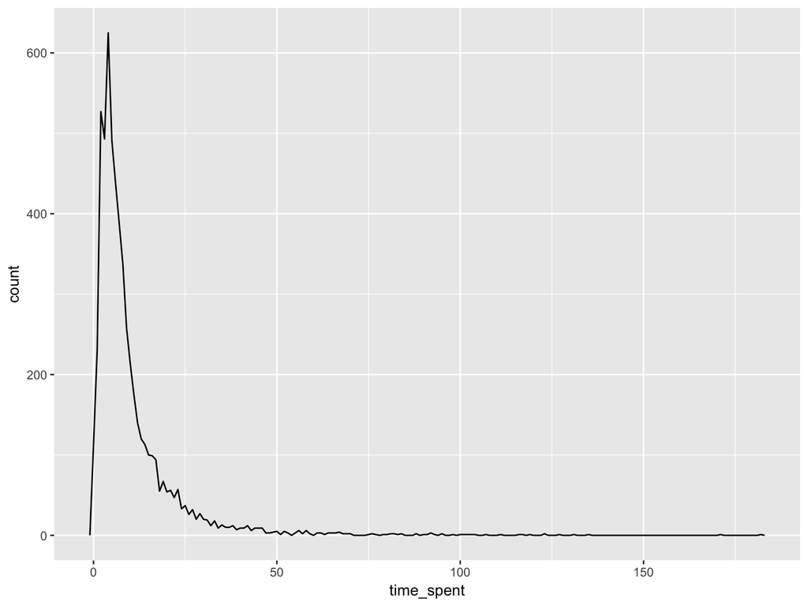

```r
  # And plot the frequency distribution of the time spent by the patients
  MIMIC3_adm_dis %>%
  ggplot(aes(time_spent)) +
    geom_freqpoly(binwidth = 1)
```

time difference can be little painful to work with when we are interested in durations. The library lubridate provides an alternative which always uses seconds: the **duration**.

We can convert our variable into duration by using the function `as.duration()`.

```r
  # Convert the time spent as duration (in seconds)
  MIMIC3_adm_dis <- MIMIC3_adm_dis %>%
                    mutate(time_spent_in_seconds = as.duration(time_spent))
  as.tibble(MIMIC3_adm_dis)
```

```
## # A tibble: 5,770 x 5
##   hadm_id  admittime  dischtime time_spent time_spent_in_seconds
##     <int>     <date>     <date>     <time>        <S4: Duration>
## 1  110641 2150-06-24 2150-06-29     5 days     432000s (~5 days)
## 2  158569 2142-04-01 2142-04-08     7 days    604800s (~1 weeks)
## 3  120969 2196-02-02 2196-02-04     2 days     172800s (~2 days)
## 4  166401 2196-04-14 2196-04-17     3 days     259200s (~3 days)
## 5  116630 2162-03-02 2162-03-10     8 days 691200s (~1.14 weeks)
## 6  112077 2167-07-25 2167-07-30     5 days     432000s (~5 days)
## 7  190243 2146-04-06 2146-04-10     4 days     345600s (~4 days)
## # ... with 5,763 more rows
```

Durations come with a bunch of convenient constructors:

```r
  # List the duration of 15s
  dseconds(15)
  # List the duration in 10 minutes
  dminutes(10)
  # List the duration in 12 hrs and 24 hours
  dhours(c(12, 24))
  # List the duration from 0 to 5 days
  ddays(0:5)
  # List the duration in 3 weeks
  dweeks(3)
  # List the duration in a year
  dyears(1)
```

```
## [1] "15s"
```

```
## [1] "600s (~10 minutes)"
```

```
## [1] "43200s (~12 hours)" "86400s (~1 days)"
```

```
## [1] "0s"                "86400s (~1 days)"  "172800s (~2 days)"
## [4] "259200s (~3 days)" "345600s (~4 days)" "432000s (~5 days)"
```

```
## [1] "1814400s (~3 weeks)"
```

```
## [1] "31536000s (~52.14 weeks)"
```

These constructors can help convert our years by a 200 year offset. Or alternatively we can use periods.

**Periods** are time spans but don’t have a fixed length in seconds, instead they work with “human” times, like days and months.

That allows them work in a more intuitive way. Like durations, periods can be created with a number of friendly constructor functions.

```r
  # Make 15s
  seconds(15)
  # Make 10m
  minutes(10)
  # Make 12 hrs and 24 hrs
  hours(c(12, 24))
  # Make 7 days
  days(7)
  # Make 1-6 months
  months(1:6)
  # Make 3 weeks
  weeks(3)
  # Make 1 year
  years(1)
```

```
## [1] "15S"
```

```
## [1] "10M 0S"
```

```
## [1] "12H 0M 0S" "24H 0M 0S"
```

```
## [1] "7d 0H 0M 0S"
```

```
## [1] "1m 0d 0H 0M 0S" "2m 0d 0H 0M 0S" "3m 0d 0H 0M 0S" "4m 0d 0H 0M 0S"
## [5] "5m 0d 0H 0M 0S" "6m 0d 0H 0M 0S"
```

```
## [1] "21d 0H 0M 0S"
```

```
## [1] "1y 0m 0d 0H 0M 0S"
```

You can add and multiply periods and add them to dates. Thus we can subtract a 200 year time peroid from our admission and discharge times:

```r
  # Makes times compatible with our times subtracting 200 years
  MIMIC3_adm_dis <- MIMIC3_adm_dis %>%
                    mutate(admission_time_minus_200 = ymd(admittime)-years(200),
                    dischtime_time_minus_200 = ymd(dischtime)-years(200)) %>%
                    select(admission_time_minus_200,dischtime_time_minus_200, everything())
  as.tibble(MIMIC3_adm_dis)
```

```
## # A tibble: 5,770 x 7
##   admission_time_minus_200 dischtime_time_minus_200 time_spent hadm_id
##                     <date>                   <date>     <time>   <int>
## 1               1950-06-24               1950-06-29     5 days  110641
## 2               1942-04-01               1942-04-08     7 days  158569
## 3               1996-02-02               1996-02-04     2 days  120969
## 4               1996-04-14               1996-04-17     3 days  166401
## 5               1962-03-02               1962-03-10     8 days  116630
## 6               1967-07-25               1967-07-30     5 days  112077
## 7               1946-04-06               1946-04-10     4 days  190243
## # ... with 5,763 more rows, and 3 more variables: admittime <date>,
## #   dischtime <date>, time_spent_in_seconds <S4: Duration>
```

We can then look at the frequency of discharge over the hundred year period 1900-now.

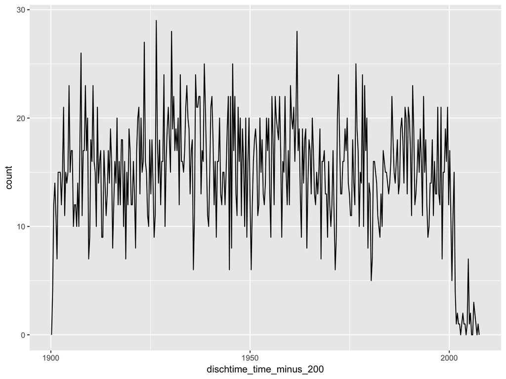

```r
  # Load the above admissions and discharge data
  MIMIC3_adm_dis %>%
  # And plot the frequency distribution of discharge
  ggplot(aes(dischtime_time_minus_200)) +
    geom_freqpoly(binwidth = 100)
```

Or for a single year, say 1980, distributed over a month:

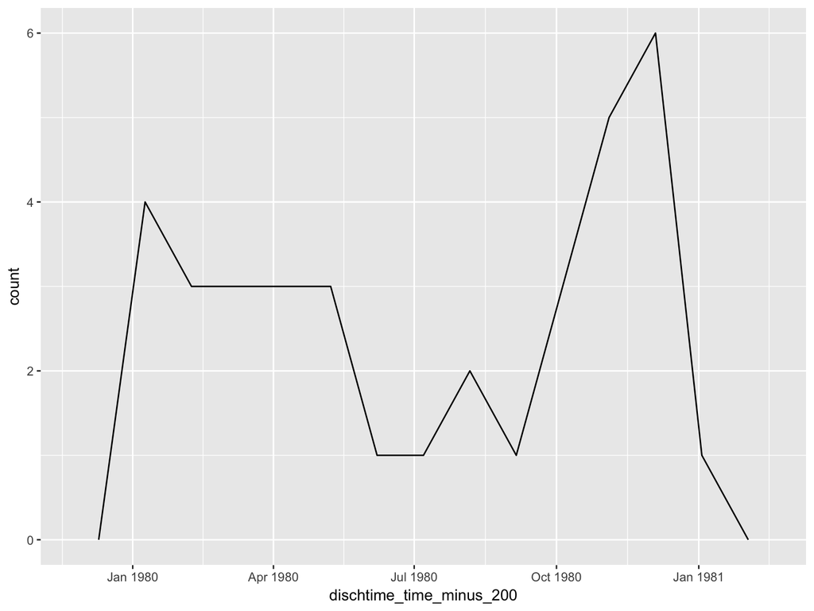

```r
  # Load the above admissions and discharge data
  MIMIC3_adm_dis %>%
  # and filter for the discharges in the year 1980
  filter(dischtime_time_minus_200 >= ymd(19800101) & dischtime_time_minus_200 <= ymd(19801231)) %>%
  # And plot the frequency distribution for 30 days
  ggplot(aes(dischtime_time_minus_200)) +
    geom_freqpoly(binwidth = 30)
```

What should `years(1) / days(1)` return? Is it 365 or 366, since some years are leap years and periods are human interpretable values unlike duration? R will throw a warning if we try to perfom this operation.

```r
  # Find years(1) / days(1)
  years(1) / days(1)
```

```
## estimate only: convert to intervals for accuracy
```

```
## [1] 365.25
```

Thus we have to use an **interval**. An interval is a duration with a starting point: that makes it precise so you can determine exactly how long it is:

```r
  # Find years(1) / days(1) by converting to interval
  next_year <- today() + years(1)
  (today() %--% next_year) / ddays(1)
```

```
## [1] 365
```

**Classwork/Homework**: Read section 16.5 Date-time components in the book R for Data Science.

#### Tidying data

Same “kind of” data can be present in multiple columns that may denote a single variable. For example, consider MIMIC3 admissions table. There are two variables - `edregtime` and `edouttime` (emergency department registration time and emergency department out time, respectively) that represents one variable: `time stamp in emergency`, a larger class of variable.

```r
  # Select subject_id, hadm_id, edregtime and edouttime variables
  MIMIC3_ADM_tibble <- MIMIC3_ADM %>% select(subject_id,hadm_id,edregtime,edouttime) %>% na.omit()
  as.tibble(MIMIC3_ADM_tibble)
```

```
## # A tibble: 3,065 x 4
##   subject_id hadm_id           edregtime           edouttime
## *      <int>   <int>              <fctr>              <fctr>
## 1         84  166401 2196-04-13 22:23:00 2196-04-14 04:31:00
## 2         85  112077 2167-07-25 16:37:00 2167-07-25 20:46:00
## 3         88  123010 2111-08-29 01:44:00 2111-08-29 02:28:00
## 4         91  121205 2177-04-22 21:02:00 2177-04-23 04:03:00
## 5         94  183686 2176-02-25 10:35:00 2176-02-25 18:14:00
## 6         94  140037 2176-09-02 09:54:00 2176-09-02 17:56:00
## 7         95  160891 2157-12-25 12:24:00 2157-12-25 16:56:00
## # ... with 3,058 more rows
```

The purpose of the **gather** function is to tidy the data by aggregating such data present in multiple columns into a new pair of variables. To accomplish this, we need three parameters:

- The set of columns that represent sub-classification/sub-variables. In this example, those are the columns `edregtime` and `edouttime`
- The name of a single variable that represents a larger class. This is called a key, and here it is `time stamp in emergency`. Lets call this variable `EdTimeStamp`.
- The values that are present in the cells corresponding to the sub-variables. Here it’s the time stamp when registering and when out of the emergency department. Lets call this variable `time`

Once we have these parameters, we can *gather* data:

```r
  # Gather edregtime and edouttime, to form variable "EdTimeStamp" with
  # value "time"
  MIMIC3_ADM_gather <- MIMIC3_ADM_tibble %>%
    gather(`edregtime`, `edouttime`, key = "EdTimeStamp", value = "time")
  as.tibble(MIMIC3_ADM_gather)
```

```
## # A tibble: 6,130 x 4
##   subject_id hadm_id EdTimeStamp                time
##        <int>   <int>       <chr>               <chr>
## 1         84  166401   edregtime 2196-04-13 22:23:00
## 2         85  112077   edregtime 2167-07-25 16:37:00
## 3         88  123010   edregtime 2111-08-29 01:44:00
## 4         91  121205   edregtime 2177-04-22 21:02:00
## 5         94  183686   edregtime 2176-02-25 10:35:00
## 6         94  140037   edregtime 2176-09-02 09:54:00
## 7         95  160891   edregtime 2157-12-25 12:24:00
## # ... with 6,123 more rows
```

**Classwork/Homework**: Find the number of times each patient was registered in emergency department.

**Spreading** is the opposite of gathering. We use it when an observation is scattered across multiple rows. For example, in the above data set, the patient denoted by `subject_id` can have several hospital admission id `hadm_id` depending on how many times they were admitted in the hospital.

To spread this data, we first analyse the representation in similar way to `gather()`. This time, however, we only need two parameters:

- The column that contains the key column. Here, it’s `subject_id`.
- The column that contains multiple values for the key column, the values column. Here it’s `hadm_id`.

Once we have these two parameters we can *spread* the data:

```r
  # Spread each patient (subject_id) for the hospital admission id - hadm_id
  MIMIC3_ADM_spread <- MIMIC3_ADM_tibble %>% head() %>%
    spread(key = subject_id, value = hadm_id) %>% select(`edregtime`, `edouttime`, '94', everything())
  as.tibble(MIMIC3_ADM_spread)
```

```
## # A tibble: 6 x 7
##             edregtime           edouttime   `94`   `84`   `85`   `88`
## *              <fctr>              <fctr>  <int>  <int>  <int>  <int>
## 1 2111-08-29 01:44:00 2111-08-29 02:28:00     NA     NA     NA 123010
## 2 2167-07-25 16:37:00 2167-07-25 20:46:00     NA     NA 112077     NA
## 3 2176-02-25 10:35:00 2176-02-25 18:14:00 183686     NA     NA     NA
## 4 2176-09-02 09:54:00 2176-09-02 17:56:00 140037     NA     NA     NA
## 5 2177-04-22 21:02:00 2177-04-23 04:03:00     NA     NA     NA     NA
## 6 2196-04-13 22:23:00 2196-04-14 04:31:00     NA 166401     NA     NA
## # ... with 1 more variables: `91` <int>
```

We immediately see that patient no. 94 had two admissions in the hospital as emergency visits.

`separate()` pulls apart one column into multiple columns, by splitting wherever a separator character appears. For example, consider the `admissions_location` variable. Its made of 9 possible values:

- EMERGENCY ROOM ADMIT
- TRANSFER FROM HOSP/EXTRAM
- TRANSFER FROM OTHER HEALT
- CLINIC REFERRAL/PREMATURE
- INFO NOT AVAILABLE
- TRANSFER FROM SKILLED NUR
- TRSF WITHIN THIS FACILITY
- HMO REFERRAL/SICK
- PHYS REFERRAL/NORMAL DELI

```r
  # Separate admission_location information
  MIMIC3_ADM_LOC_SEP <- MIMIC3_ADM %>% select(admission_location) %>%
    separate(admission_location, into = c("Info1", "Info2"), sep = "/", convert = FALSE)
  as.tibble(MIMIC3_ADM_LOC_SEP)
```

```
## # A tibble: 5,770 x 2
##                  Info1       Info2
## *                <chr>       <chr>
## 1        PHYS REFERRAL NORMAL DELI
## 2   TRANSFER FROM HOSP      EXTRAM
## 3        PHYS REFERRAL NORMAL DELI
## 4 EMERGENCY ROOM ADMIT        <NA>
## 5      CLINIC REFERRAL   PREMATURE
## 6      CLINIC REFERRAL   PREMATURE
## 7        PHYS REFERRAL NORMAL DELI
## # ... with 5,763 more rows
```

By default `seperate()` would coerce into charector vectors even if we seperate numerical variables. To retain numerical type, we have to set `convert = TRUE` argument.

`unite()` is the inverse of `separate()`: it combines multiple columns into a single column.

For example, in the above data set we can *unite* hospital admission id `hadm_id` and the admission type `admission_type` to tie a reason why the patient got admitted. By default the unite will use underscore.

This can be overridden by using a seperator argument. This is done as follows:

```r
  # Unite hadm_id and admission_type
  MIMIC3_ADM_LOC_UNITE <- MIMIC3_ADM %>% select(subject_id, hadm_id, admission_type) %>%
    unite(reason, hadm_id, admission_type, sep=":")
  as.tibble(MIMIC3_ADM_LOC_UNITE)
```

```
## # A tibble: 5,770 x 2
##   subject_id           reason
## *      <int>            <chr>
## 1         82   110641:NEWBORN
## 2         83    158569:URGENT
## 3         84  120969:ELECTIVE
## 4         84 166401:EMERGENCY
## 5         85 116630:EMERGENCY
## 6         85 112077:EMERGENCY
## 7         86  190243:ELECTIVE
## # ... with 5,763 more rows
```

#### Missing values

Missing values can be:

1. Explicit and flagged with NA
2. Implicit with values absent

Consider this data:

```r
  # Make a tibble reporting the data on people affected with influenza
  influenza <- tibble(
    year   = c(2015, 2015, 2015, 2015, 2016, 2016, 2016),
    qtr    = c(   1,    2,    3,    4,    2,    3,    4),
    no_sick = c(800, 450, 377,   NA, 900, 1300, 1257)
  )
  influenza
```

```
## # A tibble: 7 x 3
##    year   qtr no_sick
##   <dbl> <dbl>   <dbl>
## 1  2015     1     800
## 2  2015     2     450
## 3  2015     3     377
## 4  2015     4      NA
## 5  2016     2     900
## 6  2016     3    1300
## 7  2016     4    1257
```

There are two missing values in this dataset:

The no of sick people for the fourth quarter of 2015 is explicitly missing, because the cell where its value should be instead contains NA.

The no of sick people for the first quarter of 2016 is implicitly missing, because it simply does not appear in the dataset.

There are several ways we can deal with the missing values.

1. We can make the implicit missing value explicit by putting years in the columns:

```r
  # Spread the data to make implicit absense explicit
  influenza %>%
  spread(year, no_sick)
```

```
## # A tibble: 4 x 3
##     qtr `2015` `2016`
## * <dbl>  <dbl>  <dbl>
## 1     1    800     NA
## 2     2    450    900
## 3     3    377   1300
## 4     4     NA   1257
```

2. Explicit missing values may not be important in other representations of the data so we can set `na.rm = TRUE` in `gather()` to turn explicit missing values implicit:

```r
  # Spread the data to make implicit absense explicit and
  # gather with na.rm = TRUE to turn explicit missing values implicit
  influenza %>%
  spread(year, no_sick) %>%
  gather(year, no_sick, `2015`:`2016`, na.rm = TRUE)
```

```
## # A tibble: 6 x 3
##     qtr  year no_sick
## * <dbl> <chr>   <dbl>
## 1     1  2015     800
## 2     2  2015     450
## 3     3  2015     377
## 4     2  2016     900
## 5     3  2016    1300
## 6     4  2016    1257
```

3. We can use `complete()` which takes a set of columns, and finds all unique combinations. It then ensures the original dataset contains all those values, filling in explicit NAs where necessary:

```r
  # Complete the data by finding the combinations and replacing NA
  influenza %>%
  complete(year, qtr)
```

```
## # A tibble: 8 x 3
##    year   qtr no_sick
##   <dbl> <dbl>   <dbl>
## 1  2015     1     800
## 2  2015     2     450
## 3  2015     3     377
## 4  2015     4      NA
## 5  2016     1      NA
## 6  2016     2     900
## 7  2016     3    1300
## 8  2016     4    1257
```

4. Or we can use `fill()` which takes a set of columns where you want missing values to be replaced by the most recent non-missing value (sometimes called last observation carried forward).

```r
  # Fill NA with the most recent value found - 377 in this case
  influenza %>%
  fill(no_sick)
```

```
## # A tibble: 7 x 3
##    year   qtr no_sick
##   <dbl> <dbl>   <dbl>
## 1  2015     1     800
## 2  2015     2     450
## 3  2015     3     377
## 4  2015     4     377
## 5  2016     2     900
## 6  2016     3    1300
## 7  2016     4    1257
```

**Classwork/Homework**: Read section 12.6 in the book. It contains a case study on World Health Organization Global Tuberculosis Report conducted in 2014.

#### Selected materials and references

[R for Data Science - Wrangle Part](http://r4ds.had.co.nz/wrangle-intro.html)